# HW1

## Step 2

```r
data05$Date = as.Date(data05$Date, format = "%m/%d/%Y")
data25$Date = as.Date(data25$Date, format = "%m/%d/%Y")

data05$Year = format(data05$Date, "%Y")
data25$Year = format(data25$Date, "%Y")

names(data05)[names(data05) == "Daily.Mean.PM2.5.Concentration"] = "PM25"
names(data25)[names(data25) == "Daily.Mean.PM2.5.Concentration"] = "PM25"

data_all = rbind(data05, data25)

dim(data_all)
```

```
[1] 15217    23
```

```r
table(data_all$Year)
```

```
2005 2025
5280 9937
```

## Step 3

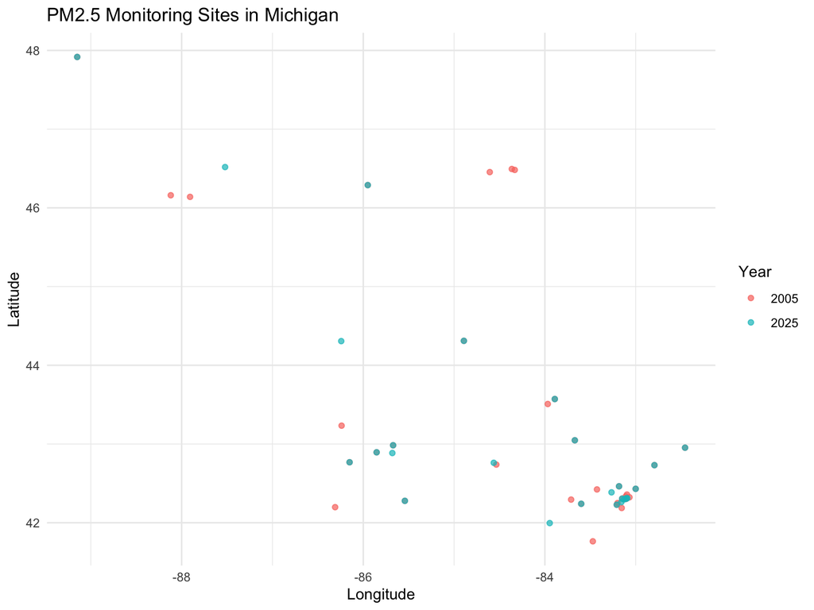

```r
library(ggplot2)
data_all$Year = as.factor(data_all$Year)
site_data = unique(data_all[, c("Site.ID",
                                 "Site.Latitude",
                                 "Site.Longitude",
                                 "Year")])

ggplot(site_data,
       aes(x = Site.Longitude,
           y = Site.Latitude,
           color = Year)) +
  geom_point(alpha = 0.7) +
  labs(title = "PM2.5 Monitoring Sites in Michigan",
       x = "Longitude",
       y = "Latitude") +
  theme_minimal()
```

The monitoring sites are distributed across the state of Michigan, with most locations concentrated in the southern and southeastern regions. Fewer sites are present in the northern areas, indicating that monitoring coverage is denser in more populated or urban regions.

Comparing 2005 and 2025, the overall spatial pattern of monitoring locations appears largely similar, as most sites remain in comparable geographic regions. However, there are some localized differences. For example, a few monitoring sites appear in the northeastern area in 2005 that are not present in 2025, while several additional sites are introduced in other southern regions in 2025.

## Step 4

```r
mean(is.na(data_all$PM25))
```

```
[1] 0
```

```r
tapply(is.na(data_all$PM25), data_all$Year, mean)
```

```
2005 2025
   0    0
```

```r
sum(data_all$PM25 < 0, na.rm = TRUE)
```

```
[1] 0
```

```r
summary(data_all$PM25)
```

```
   Min. 1st Qu.  Median    Mean 3rd Qu.    Max.
    0.0     4.5     7.4    10.2    12.5   116.0
```

```r
table(data_all$Method.Code)
```

```
 118  145  170  636  638  707  781  810
4367  324 1733 3941 1336  322   44  607
```

```r
table(data_all$Year, data_all$Method.Code)
```

```
        118  145  170  636  638  707  781  810
  2005 4367    0    0    0    0  262   44  607
  2025    0  324 1733 3941 1336   60    0    0
```

```r
sort(table(data_all$Method.Code), decreasing = TRUE)[1:2]
```

```
 118  636
4367 3941
```

```r
prop.table(table(data_all$Year, data_all$Method.Code), 1)
```

```
               118         145         170         636         638         707
  2005 0.827083333 0.000000000 0.000000000 0.000000000 0.000000000 0.049621212
  2025 0.000000000 0.043819313 0.234379226 0.532999730 0.180687044 0.008114688

               781         810
  2005 0.008333333 0.114962121
  2025 0.000000000 0.000000000
```

The combined dataset was examined for potential data quality issues in PM2.5 measurements. The proportion of missing PM2.5 values was 0% overall and 0% for both 2005 and 2025, indicating no missing observations. Additionally, no negative PM2.5 values were found, suggesting there are no clearly implausible measurements. Summary statistics show a right-skewed distribution with a maximum value of 116 µg/m³, which is high but still plausible during extreme pollution events rather than a data entry error.

The distribution of measurement methods varies substantially across years. The two most common method codes in the combined dataset are Method 118 and Method 636, which together account for the majority of observations. However, their usage differs sharply by year.

In 2005, Method 118 dominates the dataset, accounting for approximately 83% of all measurements, with smaller contributions from Methods 707 and 810.

In contrast, 2025 shows a shift toward newer or different methods, with Method 636 representing about 53% of observations and Method 170 about 23%, while Method 118 is no longer present.

This temporal shift in method codes suggests that measurement technologies or monitoring protocols changed over time. These differences are important because changes in instrumentation or sampling methodology may influence the comparability of PM2.5 measurements across years. Therefore, observed trends in air pollution levels could partially reflect methodological differences rather than purely environmental change.

## Step 5

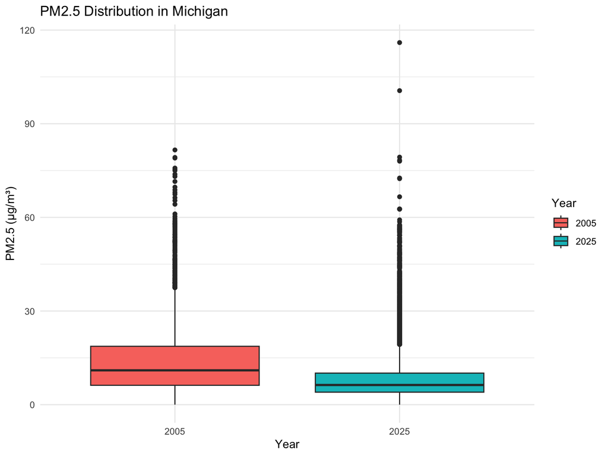

```r
# State level
ggplot(data_all, aes(x = Year, y = PM25, fill = Year)) +
  geom_boxplot() +
  labs(title = "PM2.5 Distribution in Michigan",
       y = "PM2.5 (µg/m³)") +
  theme_minimal()
```

```r
aggregate(PM25 ~ Year, data_all, mean)
```

```
  Year      PM25
1 2005 13.772311
2 2025  8.300121
```

```r
aggregate(PM25 ~ Year, data_all, median)
```

```
  Year PM25
1 2005 11.0
2 2025  6.3
```

```r
aggregate(PM25 ~ Year, data_all, sd)
```

```
  Year      PM25
1 2005 10.412844
2 2025  7.417364
```

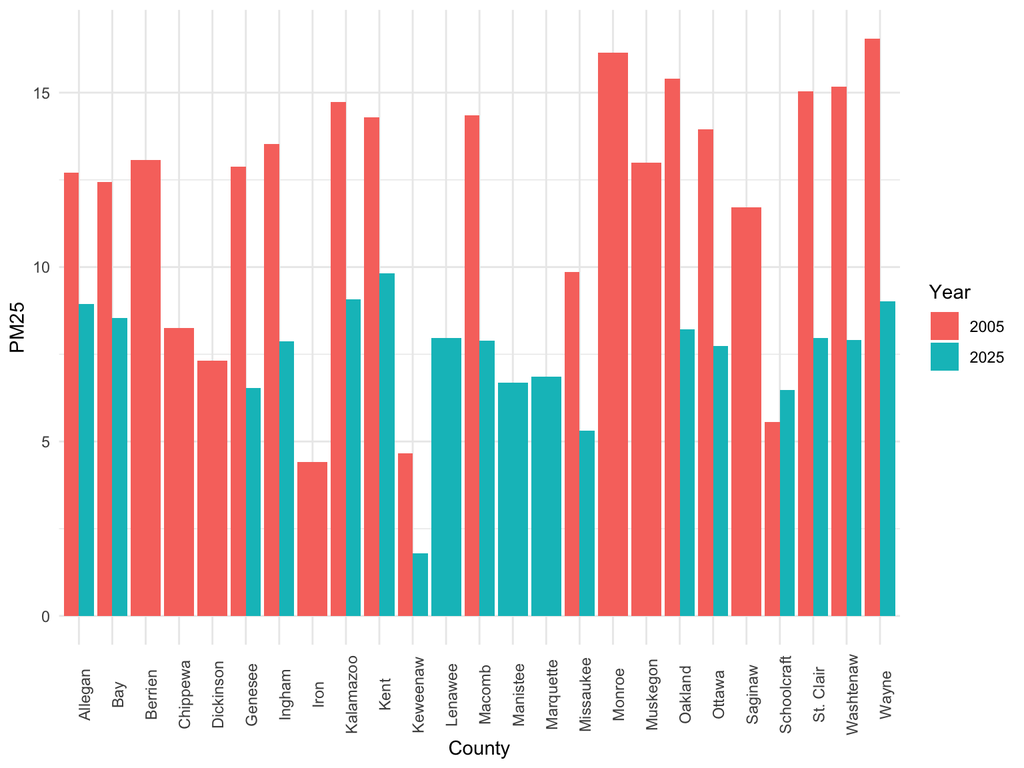

```r
# County level
county_mean = aggregate(PM25 ~ County + Year, data_all, mean)

ggplot(county_mean,
       aes(x = County, y = PM25, fill = Year)) +
  geom_bar(stat = "identity", position = "dodge") +
  theme_minimal() +
  theme(axis.text.x = element_text(angle = 90))
```

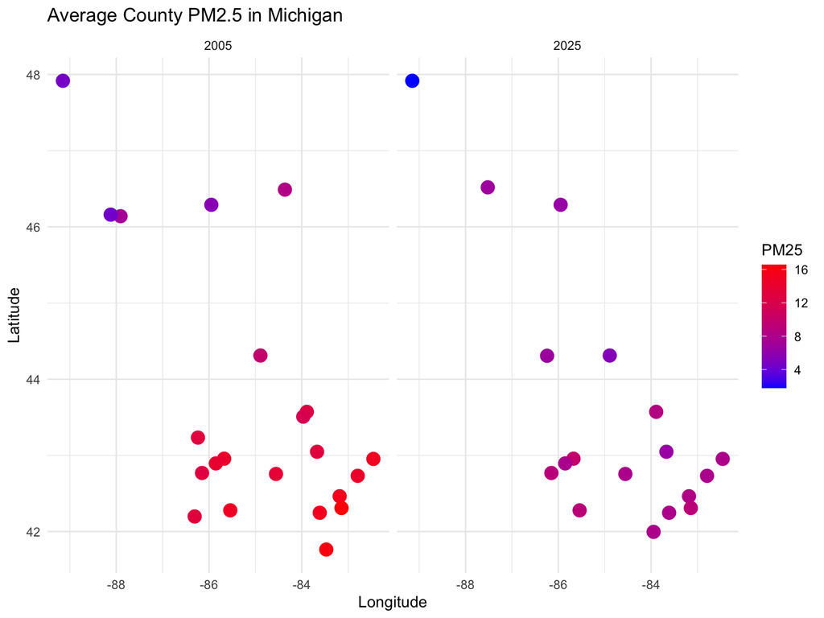

```r
county_coord = aggregate(cbind(Site.Latitude, Site.Longitude) ~ County,
                          data_all,
                          mean)
county_map = merge(county_mean, county_coord, by = "County")
ggplot(county_map,
       aes(x = Site.Longitude,
           y = Site.Latitude,
           color = PM25)) +
  geom_point(size = 4) +
  facet_wrap(~Year) +
  scale_color_gradient(low = "blue", high = "red") +
  labs(title = "Average County PM2.5 in Michigan",
       x = "Longitude",
       y = "Latitude") +
  theme_minimal()
```

```r
county_wide = reshape(county_mean,
                       idvar = "County",
                       timevar = "Year",
                       direction = "wide")

county_wide$diff = county_wide$PM25.2005 - county_wide$PM25.2025
county_wide
```

```
        County PM25.2005 PM25.2025       diff
1      Allegan 12.706651  8.946797  3.7598542
2          Bay 12.430769  8.536486  3.8942827
3      Berrien 13.063559        NA         NA
4     Chippewa  8.249735        NA         NA
5    Dickinson  7.320000        NA         NA
6      Genesee 12.880672  6.539286  6.3413866
7       Ingham 13.535833  7.866391  5.6694421
8         Iron  4.404000        NA         NA
9    Kalamazoo 14.734649  9.072682  5.6619674
10        Kent 14.288632  9.811055  4.4775763
11    Keweenaw  4.657143  1.800000  2.8571429
12      Macomb 14.357500  7.884110  6.4733904
13   Missaukee  9.855689  5.315385  4.5403040
14      Monroe 16.152071        NA         NA
15    Muskegon 12.999138        NA         NA
16     Oakland 15.399153  8.211507  7.1876457
17      Ottawa 13.941026  7.735342  6.2056832
18     Saginaw 11.714035        NA         NA
19 Schoolcraft  5.564103  6.481303 -0.9172006
20   St. Clair 15.046847  7.970879  7.0759677
21   Washtenaw 15.165306  7.913091  7.2522146
22       Wayne 16.549057  9.013609  7.5354471
30     Lenawee        NA  7.973973         NA
32    Manistee        NA  6.690529         NA
33   Marquette        NA  6.851136         NA
```

```r
# City level
wayne = subset(data_all, County == "Wayne")
site_mean = aggregate(PM25 ~ Site.ID + Year, wayne, mean)
site_mean
```

```
     Site.ID Year      PM25
1  261630001 2005 16.267878
2  261630015 2005 17.195614
3  261630016 2005 16.024260
4  261630019 2005 16.419658
5  261630025 2005 14.888596
6  261630033 2005 18.891176
7  261630036 2005 16.447788
8  261630038 2005 16.384000
9  261630039 2005 15.037143
10 261639901 2005 19.588636
11 261630001 2025  7.961883
12 261630015 2025  9.234056
13 261630019 2025  7.570879
14 261630033 2025  9.348817
15 261630093 2025 11.575630
16 261630097 2025  8.332329
17 261630098 2025  9.666667
18 261630099 2025  9.143014
19 261630100 2025  8.425344
```

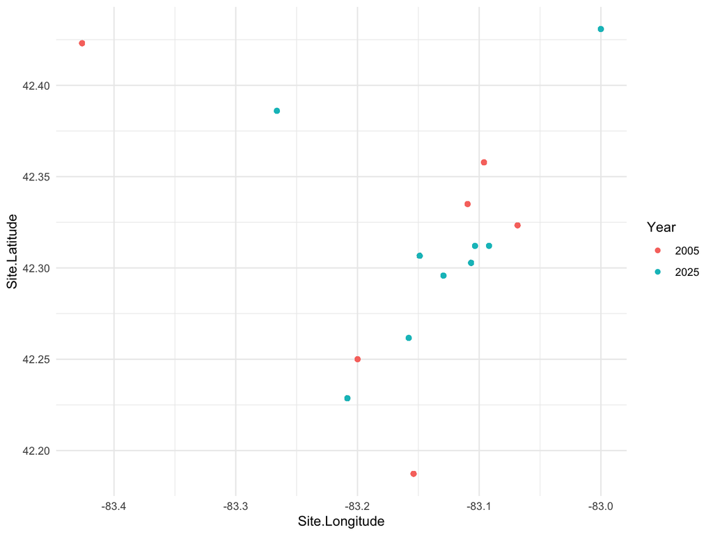

```r
ggplot(wayne,
       aes(x = Site.Longitude,
           y = Site.Latitude,
           color = Year)) +
  geom_point() +
  theme_minimal()
```

At the state level, PM2.5 concentrations show a clear decline from 2005 to 2025. The boxplot indicates that the median and interquartile range are both lower in 2025, suggesting an overall improvement in air quality. Summary statistics support this pattern, with the mean decreasing from approximately 13.8 µg/m3 in 2005 to 8.3 µg/m3 in 2025, and the median decreasing from 11.0 to 6.3. Although extreme outliers remain in both years, typical daily pollution levels are substantially lower in 2025.